# draft_techincal_report

```r
# Read the data
parkrun_data <- read.csv("clean-data.csv")

# Clean and prepare the data - using grade for elite classification
clean_data <- parkrun_data %>%
  filter(!is.na(Time_seconds) & Time_seconds > 0 & !is.na(grade)) %>%
  mutate(
    Time_minutes = Time_seconds / 60,
    elite_runner = grade >= 70,
    week = as.factor(week),
    Gender = factor(Gender, levels = c("M", "F"))
  )
```

To distinguish a normal runner and an elite runner, I used the argument “Age grade” which is a percentage that compares runner’s time to the world record for runner’s age and gender.

This percentage could be understood as: - <50% = beginner - 50-60% = average - 60-70% = good - 70-80% = very good - 80%+ = excellent

I chose 70% as a threshold which means any runners that have the ‘Age grade’ above 70 are considered as an elite runner.

I divided into 2 categories

```r
# QUESTION 1: TARGETING ELITE RUNNERS USING GRADE

# 1.1 Analyze elite runners by location and gender
elite_analysis_gender <- clean_data %>%
  group_by(parkrun, Gender) %>%
  summarise(
    total_runners = n(),
    elite_runners = sum(elite_runner),
    elite_percentage = elite_runners / total_runners * 100,
    avg_grade = mean(grade, na.rm = TRUE),
    max_grade = max(grade, na.rm = TRUE)
  ) %>%
  arrange(parkrun)
elite_analysis_gender %>%
  kable(
    caption = "Table 1. Elite Analysis by Gender and Parkrun Location",
    digits = 2
  )
```

Table 1. Elite Analysis by Gender and Parkrun Location

| parkrun | Gender | total_runners | elite_runners | elite_percentage | avg_grade | max_grade |
| --- | --- | --- | --- | --- | --- | --- |
| broadpark | M | 584 | 19 | 3.25 | 49.74 | 80.28 |
| broadpark | F | 641 | 22 | 3.43 | 47.96 | 84.31 |
| foster | M | 1066 | 75 | 7.04 | 53.86 | 88.35 |
| foster | F | 952 | 26 | 2.73 | 46.63 | 86.23 |
| hagley | M | 2792 | 331 | 11.86 | 54.97 | 90.27 |
| hagley | F | 2482 | 156 | 6.29 | 50.83 | 92.03 |
| halswellquarry | M | 457 | 1 | 0.22 | 45.33 | 72.54 |
| halswellquarry | F | 312 | 0 | 0.00 | 40.02 | 63.66 |
| pegasus | M | 779 | 69 | 8.86 | 53.51 | 81.87 |
| pegasus | F | 721 | 40 | 5.55 | 50.88 | 85.84 |
| riverlution | M | 906 | 53 | 5.85 | 51.72 | 84.59 |
| riverlution | F | 998 | 37 | 3.71 | 48.22 | 85.74 |
| scarborough | M | 852 | 115 | 13.50 | 56.14 | 85.51 |
| scarborough | F | 817 | 42 | 5.14 | 51.18 | 85.58 |

```r
#print("Elite Runners Analysis by Location and Gender (Grade >= 70):")
#print(elite_analysis_gender)
```

```r
# Overall elite analysis by location
elite_analysis_overall <- clean_data %>%
  group_by(parkrun) %>%
  summarise(
    total_runners = n(),
    elite_runners = sum(elite_runner),
    elite_percentage = elite_runners / total_runners * 100,
    avg_grade = mean(grade, na.rm = TRUE)
  ) %>%
  arrange(desc(elite_runners))

elite_analysis_overall %>%
  kable(
    caption = "Table 2. Overal Elite Analysis by Parkrun Location",
    digits = 2
  )
```

Table 2. Overal Elite Analysis by Parkrun Location

| parkrun | total_runners | elite_runners | elite_percentage | avg_grade |
| --- | --- | --- | --- | --- |
| hagley | 5274 | 487 | 9.23 | 53.02 |
| scarborough | 1669 | 157 | 9.41 | 53.71 |
| pegasus | 1500 | 109 | 7.27 | 52.24 |
| foster | 2018 | 101 | 5.00 | 50.45 |
| riverlution | 1904 | 90 | 4.73 | 49.88 |
| broadpark | 1225 | 41 | 3.35 | 48.81 |
| halswellquarry | 769 | 1 | 0.13 | 43.18 |

```r
#print("Overall Elite Runners Analysis")
#print(elite_analysis_overall)
```

For technical report: - Why am I using this type of chart to visualization? - Bar charts are best for comparing quantities across different categories. - Bar graphs use rectangular bars to represent data values. They can be displayed vertically or horizontally

Pipeline: - Prepare data, using grade for elite classification - Create 2 table to analysis named: “Elite Analysis by Gender and Parkrun Location” and “Overal Elite Analysis by Parkrun Location” - Create bar chart to visualization: “elite runner counts by gender and location” and “Percentage of Elite Runners by Location and Gender”

The first is counts by gender and location

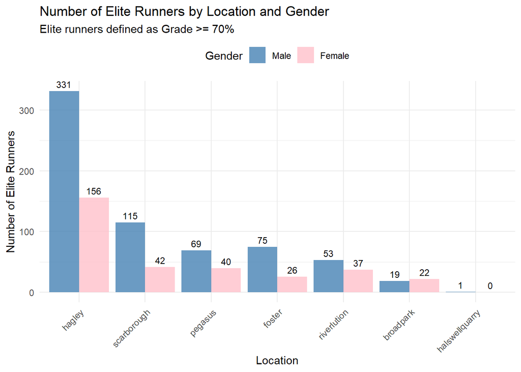

```r
# 1.2 Visualize elite runners distribution by gender

# Bar chart: Number of elite runners by location and gender
p1 <- ggplot(elite_analysis_gender, aes(x = reorder(parkrun, -elite_runners), y = elite_runners, fill = Gender)) +
  geom_bar(stat = "identity", position = "dodge", alpha = 0.8) +
  geom_text(aes(label = elite_runners),
            position = position_dodge(width = 0.9),
            vjust = -0.5, size = 3) +
  scale_fill_manual(values = c("M" = "steelblue", "F" = "pink"),
                    labels = c("M" = "Male", "F" = "Female")) +
  labs(title = "Number of Elite Runners by Location and Gender",
       subtitle = "Elite runners defined as Grade >= 70%",
       x = "Location",
       y = "Number of Elite Runners",
       fill = "Gender") +
  theme_minimal() +
  theme(axis.text.x = element_text(angle = 45, hjust = 1),
        legend.position = "top")

print(p1)
```

percentage of elite runners within each location and gender

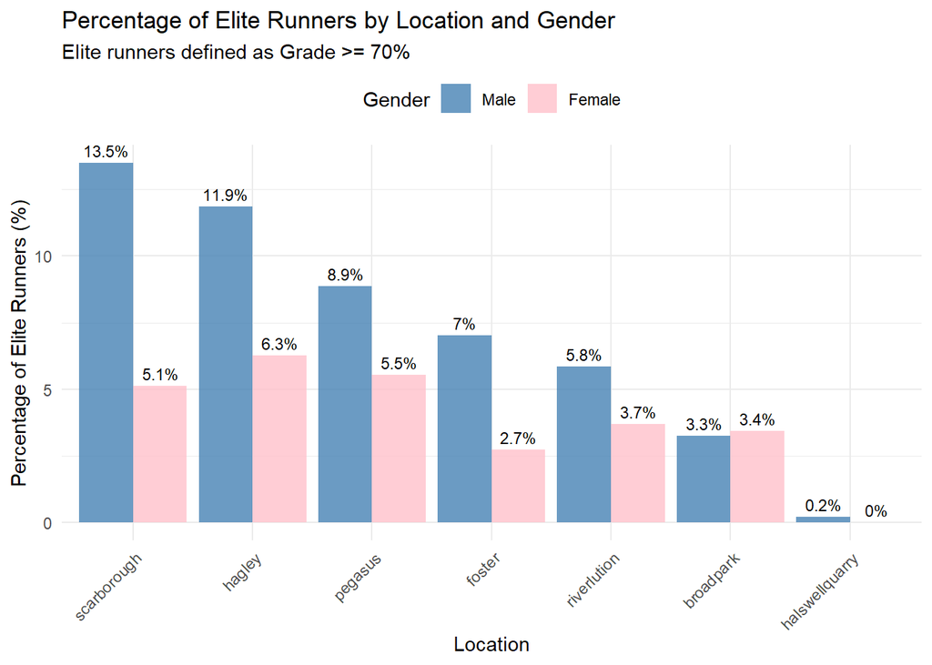

```r
# Bar chart: Percentage of elite runners by location and gender
p2 <- ggplot(elite_analysis_gender, aes(x = reorder(parkrun, -elite_percentage), y = elite_percentage, fill = Gender)) +
  geom_bar(stat = "identity", position = "dodge", alpha = 0.8) +
  geom_text(aes(label = paste0(round(elite_percentage, 1), "%")),
            position = position_dodge(width = 0.9),
            vjust = -0.5, size = 3) +
  scale_fill_manual(values = c("M" = "steelblue", "F" = "pink"),
                    labels = c("M" = "Male", "F" = "Female")) +
  labs(title = "Percentage of Elite Runners by Location and Gender",
       subtitle = "Elite runners defined as Grade >= 70%",
       x = "Location",
       y = "Percentage of Elite Runners (%)",
       fill = "Gender") +
  theme_minimal() +
  theme(axis.text.x = element_text(angle = 45, hjust = 1),
        legend.position = "top")

print(p2)
```

To find consistent runners, I find who appear in multiple weeks of parkrun data and quantifies their participation patterns (frequency, duration, and performance)

Create a table to see how many consistent runners in each parkrun. Create a stacked bar chart to see the distribution of consitent runner in each parkrun

```r
# QUESTION 2: CONSISTENT RUNNERS ANALYSIS

# 2.1 Identify consistent runners (appearing in multiple weeks)
runner_consistency <- clean_data %>%
  group_by(name_id, parkrun) %>%
  summarise(
    weeks_participated = n_distinct(week),
    total_runs = n(),
    avg_time = mean(Time_minutes),
    first_week = min(as.numeric(as.character(week))),
    last_week = max(as.numeric(as.character(week)))
  ) %>%
  mutate(
    consistency_level = case_when(
      weeks_participated >= 5 ~ "Highly Consistent (5+ weeks)",
      weeks_participated >= 3 ~ "Moderately Consistent (3-4 weeks)",
      TRUE ~ "Occasional (1-2 weeks)"
    )
  )
print(runner_consistency)
```

```
## # A tibble: 6,576 × 8
## # Groups:   name_id [4,567]
##    name_id   parkrun weeks_participated total_runs avg_time first_week last_week
##    <chr>     <chr>                <int>      <int>    <dbl>      <dbl>     <dbl>
##  1 AEURWKHU… hagley                   1          1     19.9          7         7
##  2 BCKX      hagley                   1          1     33.4          2         2
##  3 BDQ       hagley                   2          2     41.2          6        11
##  4 BEDLUG    foster                   4          4     46.9          1         8
##  5 BERCKNR   foster                   1          1     19.8          1         1
##  6 BFHGHUPDQ hagley                   1          1     36.8          2         2
##  7 BFKHQJ    halswe…                  1          1     29.1         11        11
##  8 BFKRL     hagley                   1          1     29.1          4         4
##  9 BFXQGB    hagley                   1          1     26.8          2         2
## 10 BK        pegasus                  3          3     40.8          6         8
## # ℹ 6,566 more rows
## # ℹ 1 more variable: consistency_level <chr>
```

```r
# 2.2 Consistency summary by location
consistency_by_location <- runner_consistency %>%
  group_by(parkrun) %>%
  summarise(
    total_unique_runners = n(),
    highly_consistent = sum(weeks_participated >= 5),
    moderately_consistent = sum(weeks_participated >= 3 & weeks_participated <= 4),
    occasional = sum(weeks_participated <= 2),
    pct_highly_consistent = highly_consistent / total_unique_runners * 100,
    avg_weeks_per_runner = mean(weeks_participated)
  ) %>%
  arrange(desc(avg_weeks_per_runner))

print("Runner Consistency by Location:")
```

```
## [1] "Runner Consistency by Location:"
```

```r
print(consistency_by_location)
```

```
## # A tibble: 7 × 7
##   parkrun        total_unique_runners highly_consistent moderately_consistent
##   <chr>                         <int>             <int>                 <int>
## 1 pegasus                         539               116                    76
## 2 foster                          745               138                   111
## 3 hagley                         2300               285                   330
## 4 scarborough                     809                75                   128
## 5 broadpark                       603                61                    75
## 6 halswellquarry                  449                25                    39
## 7 riverlution                    1131                56                   110
## # ℹ 3 more variables: occasional <int>, pct_highly_consistent <dbl>,
## #   avg_weeks_per_runner <dbl>
```

```r
# 2.3 Overall consistency distribution
overall_consistency <- runner_consistency %>%
  count(consistency_level) %>%
  mutate(percentage = n / sum(n) * 100)

print("Overall Consistency Distribution:")
```

```
## [1] "Overall Consistency Distribution:"
```

```r
print(overall_consistency)
```

```
## # A tibble: 5,261 × 4
## # Groups:   name_id [4,567]
##    name_id     consistency_level                     n percentage
##    <chr>       <chr>                             <int>      <dbl>
##  1 AEURWKHUWRQ Occasional (1-2 weeks)                1        100
##  2 BCKX        Occasional (1-2 weeks)                1        100
##  3 BDQ         Occasional (1-2 weeks)                1        100
##  4 BEDLUG      Moderately Consistent (3-4 weeks)     1        100
##  5 BERCKNR     Occasional (1-2 weeks)                1        100
##  6 BFHGHUPDQ   Occasional (1-2 weeks)                1        100
##  7 BFKHQJ      Occasional (1-2 weeks)                1        100
##  8 BFKRL       Occasional (1-2 weeks)                1        100
##  9 BFXQGB      Occasional (1-2 weeks)                1        100
## 10 BK          Moderately Consistent (3-4 weeks)     1        100
## # ℹ 5,251 more rows
```

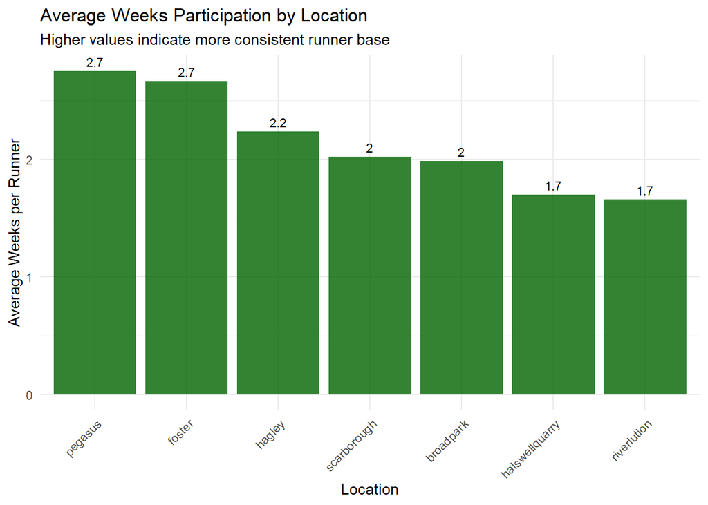

```r
# 2.4 Visualize consistency patterns

# Consistency distribution by location
p3 <- ggplot(consistency_by_location, aes(x = reorder(parkrun, -avg_weeks_per_runner), y = avg_weeks_per_runner)) +
  geom_bar(stat = "identity", fill = "darkgreen", alpha = 0.8) +
  geom_text(aes(label = round(avg_weeks_per_runner, 1)), vjust = -0.5, size = 3) +
  labs(title = "Average Weeks Participation by Location",
       subtitle = "Higher values indicate more consistent runner base",
       x = "Location", y = "Average Weeks per Runner") +
  theme_minimal() +
  theme(axis.text.x = element_text(angle = 45, hjust = 1))

print(p3)
```

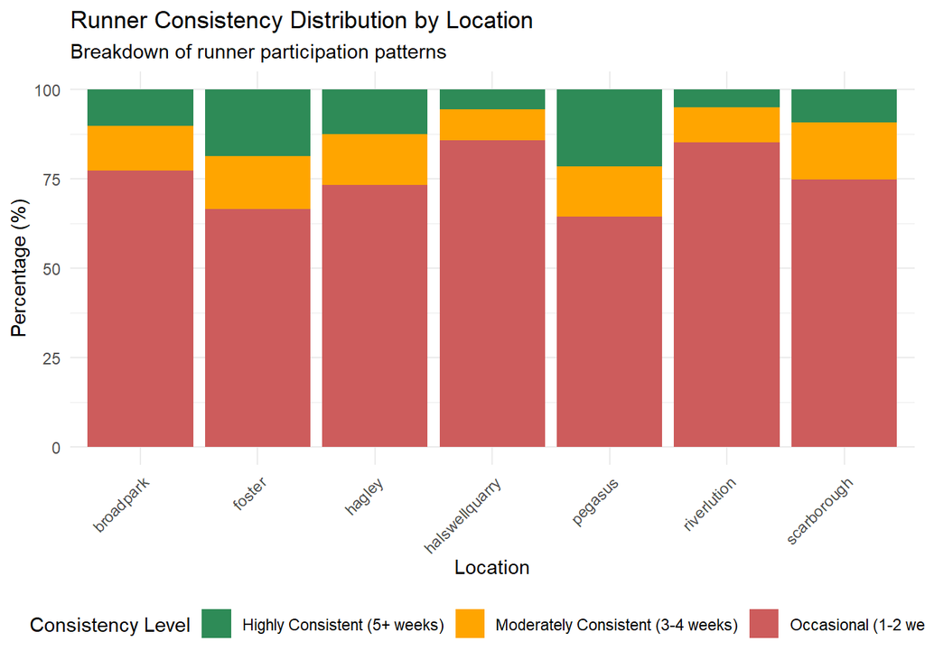

```r
# Consistency level breakdown
p4 <- runner_consistency %>%
  count(parkrun, consistency_level) %>%
  group_by(parkrun) %>%
  mutate(percentage = n / sum(n) * 100) %>%
  ggplot(aes(x = parkrun, y = percentage, fill = consistency_level)) +
  geom_bar(stat = "identity", position = "stack") +
  scale_fill_manual(values = c("Highly Consistent (5+ weeks)" = "#2E8B57",
                               "Moderately Consistent (3-4 weeks)" = "#FFA500",
                               "Occasional (1-2 weeks)" = "#CD5C5C")) +
  labs(title = "Runner Consistency Distribution by Location",
       subtitle = "Breakdown of runner participation patterns",
       x = "Location", y = "Percentage (%)", fill = "Consistency Level") +
  theme_minimal() +
  theme(axis.text.x = element_text(angle = 45, hjust = 1),
        legend.position = "bottom")

p4
```

```r
# 2.5 Time series of participation by location
weekly_participation <- clean_data %>%
  group_by(parkrun, week) %>%
  summarise(weekly_runners = n_distinct(name_id)) %>%
  mutate(week_num = as.numeric(as.character(week)))
```

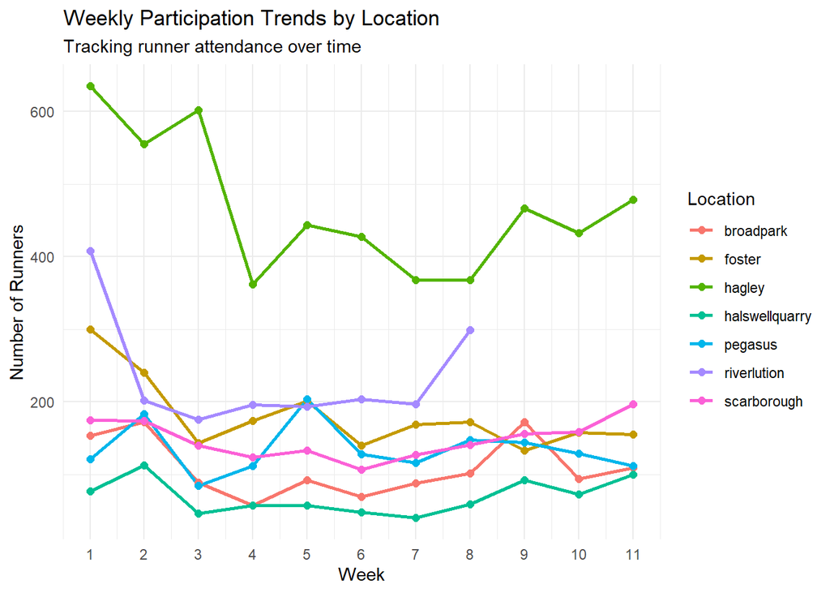

```r
p5 <- ggplot(weekly_participation, aes(x = week_num, y = weekly_runners, color = parkrun)) +
  geom_line(size = 1) +
  geom_point(size = 2) +
  labs(title = "Weekly Participation Trends by Location",
       subtitle = "Tracking runner attendance over time",
       x = "Week", y = "Number of Runners", color = "Location") +
  theme_minimal() +
  scale_x_continuous(breaks = 1:max(weekly_participation$week_num))
p5
```